# Human CRPS Combined Cohorts 16S Analysis

Rachel Rodgers & Marie Crane

January 11, 2021

# Overview

Analysis of combined human CRPS cohorts: * Run 1: 190201 (6 samples) * Run 2: 190318 (10 samples) * Run 3: 190523 (10 samples) * Run 4: 200127 (20 samples) * Run 5: 201019 (24 samples)

These cohorts include acute and chronic CRPS patients with their matched household controls, as well as unrelated, healthy "BioBank" controls.

Analyzed:

1. Three groups ("sample_type" groups):
- CRPS
- HHC
- BioBank ("healthy")
2. Six groups ("crps_match" groups):
- Acute CRPS
- Chronic CRPS
- Acute HHC
- Chronic HHC
- Acute-matched BioBank
- Chronic-matched BioBank

```r
physeqRaw <- readRDS("../data/physeqObjects/ps0.rdp_single.RDS")
physeqRaw # 2115 taxa x 69 samples
```

```
## phyloseq-class experiment-level object
## otu_table()   OTU Table:         [ 2115 taxa and 69 samples ]
## tax_table()   Taxonomy Table:    [ 2115 taxa by 7 taxonomic ranks ]
## phy_tree()    Phylogenetic Tree: [ 2115 tips and 2113 internal nodes ]
```

```r
sampleData <- readRDS("../data/sampleDataModified.RDS")
```

```r
# add readsPerSample to sample data prior to merging
readsPerSample <- sample_sums(physeqRaw)
sampleData <- mutate(sampleData,
                     "readsPerSample" = readsPerSample[sample])

row.names(sampleData) <- sampleData$sample
physeqMerged <- merge_phyloseq(physeqRaw, sample_data(sampleData))
physeqMerged # 2115 x 69
```

```
## phyloseq-class experiment-level object
## otu_table()   OTU Table:         [ 2115 taxa and 69 samples ]
## sample_data() Sample Data:       [ 69 samples by 58 sample variables ]
## tax_table()   Taxonomy Table:    [ 2115 taxa by 7 taxonomic ranks ]
## phy_tree()    Phylogenetic Tree: [ 2115 tips and 2113 internal nodes ]
```

# Quality Control

## Sample Outlier Removal by Unexpected Read Count

Checking the average read count across all samples to determine if any have unexpected numbers of reads.

```r
# sample_type = 3 groups
# crps_match = 6 groups
groupCategories <- c("sample type" = "sample_type",
                     "CRPS match" = "crps_match")

PlotAvgReads <- function(df, xVar, yVar, groupVar,
                         plotTitle = NULL, thresh = 1000,
                         labelSamples = FALSE,
                         includeStats = FALSE) {

  basePlot <- ggplot(df, aes_string(x = xVar, y = yVar, fill = groupVar)) +
    geom_boxplot(outlier.shape = NA) +
    geom_jitter(width = 0.2, alpha = 0.75) +
    geom_hline(yintercept = thresh, lty = 2) +
    ylab("Reads per Sample") +
    ggtitle(plotTitle) +
    scale_y_log10() +
    theme_pubr() +
    theme(legend.position = "none",
          plot.title = element_text(hjust = 0.5),
          axis.title.x = element_blank(),
          axis.text.x = element_text(size = 10))

  if (labelSamples == TRUE) {
    basePlot <- basePlot +
      geom_text_repel(aes(label = paste(sample, ": ", readsPerSample)),
                    data = subset(df, readsPerSample <= thresh))
  }

  if (includeStats == TRUE) {
    basePlot <- basePlot +
      stat_compare_means(method = "kruskal.test", label.x.npc = 0)
  }

  return(basePlot)

}
```

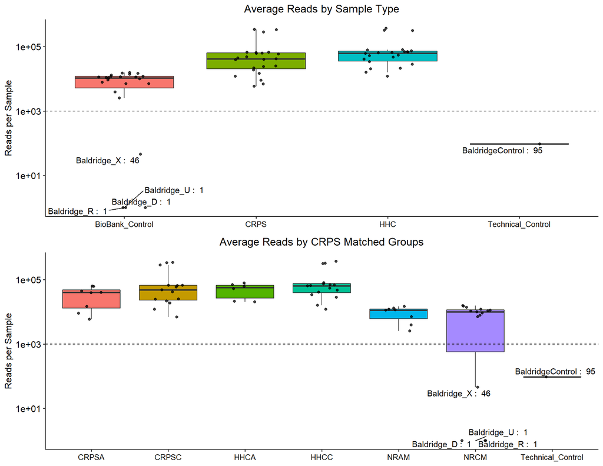

```r
avgReadsPlots <- pmap(.l = list(xVar = groupCategories,
                                groupVar = groupCategories,
                                plotTitle = c("sample type" = "Average Reads by Sample Type",
                                              "CRPS match" = "Average Reads by CRPS Matched Groups")),
                      .f = PlotAvgReads,
                      df = sampleData, yVar = "readsPerSample",
                      labelSamples = TRUE, includeStats = FALSE)

ggarrange(plotlist = avgReadsPlots, ncol = 1, nrow = 2)
```

From the box plots of average reads per group, we can see there are several BioBank control samples and a technical control with low reads. These samples will be dropped from analysis.

```r
lowReadSamples <- sampleData %>%
  filter(readsPerSample <= 1000) %>%
  pull(sample) %>%
  as.character()

physeqTrimmed <- physeqMerged %>%
  subset_samples(!(sample %in% lowReadSamples)) %>%
  RemoveMissingTaxa()
physeqTrimmed # 2108 x 64 samples
```

```
## phyloseq-class experiment-level object
## otu_table()   OTU Table:         [ 2108 taxa and 64 samples ]
## sample_data() Sample Data:       [ 64 samples by 58 sample variables ]
## tax_table()   Taxonomy Table:    [ 2108 taxa by 7 taxonomic ranks ]
## phy_tree()    Phylogenetic Tree: [ 2108 tips and 2106 internal nodes ]
```

Removal of samples having fewer than 1000 reads reduced the total samples from 69 to 64, and total taxa from 2,115 to 2,108.

Replotting average reads per group to ensure there is no significant difference in average read numbers:

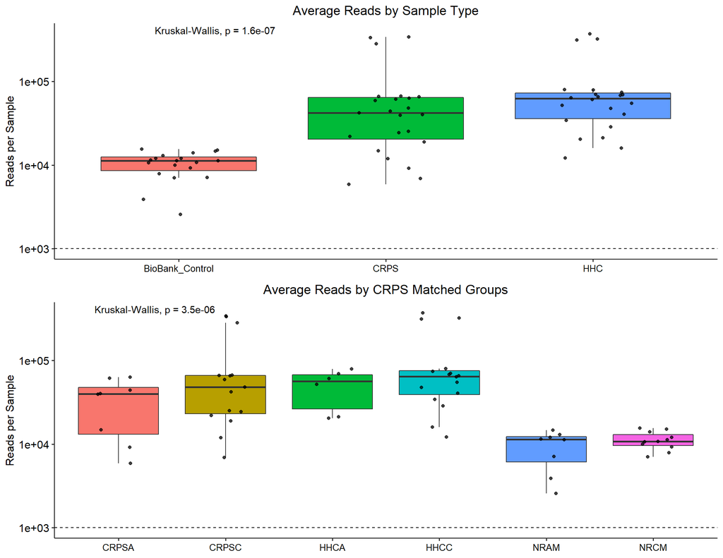

```r
sampleDataTrimmed <- as(sample_data(physeqTrimmed), "data.frame")

avgReadsPlotsTrimmed <- pmap(.l = list(xVar = groupCategories,
                                       groupVar = groupCategories,
                             plotTitle = c("sample type" = "Average Reads by Sample Type",
                                           "CRPS match" = "Average Reads by CRPS Matched Groups")),
                             .f = PlotAvgReads,
                             df = sampleDataTrimmed, yVar = "readsPerSample",
                             labelSamples = FALSE, includeStats = TRUE)

ggarrange(plotlist = avgReadsPlotsTrimmed, ncol = 1, nrow = 2)
```

Because a significant difference still exists between groups, we will rarefy the data set.